# Statdesk

Mode d’emploi

Auteur·rice

Affiliation

Arno Muller

Ined

Date de publication

07/04/2025

# Description

L’application `statdesk` permet à ses utilisateurs·rices de faire quelques analyses exploratoires simples sur le jeu de données de don choix (aux formats CSV ou Excel).

Pour l’instant l’application s’applique surtout à des variables catégorielles, mais l’intégration d’outils d’analyses de variables quantitatives est prévu dans son développement.

## Sommaire

- Import des données
- Visualisation des données
- Sélection de sous-échantillons
- Recodage des variables
- Tableaux uni- et bivariés
- Graphiques uni- et bivariés

# Accès à l’application

L’application est disponible au lien suivant :

→ https://portail-shiny-so.ined.fr/app/statdesk

# Fonctionnement

## Import des données

### Zone d’import

[figure not shown]

La première étape consiste en l’import des données dans l’application, pour y parvenir il faut renseigner plusieurs champs :

- **Format** des données : Soit au format Excel (.xlsx), soit au format CSV (.csv). Pour ce dernier il faut également renseigner le caractère utilisé pour séparer les colonnes dans un nouveau champ.
- **Séparateur des colonnes** (Uniquement pour le format CSV)
- **Choix de la base de données** : Ouvre une fenêtre de navigation dans l’explorateur des fichiers de l’ordinateur utilisé.

**Protection des données**

L’application ouvre un conteneur sécurisé dans uniquement accessible par l’utilisateur·rice qui se détruit en quittant la fenêtre. Les données importées seront donc stockées de manière temporaire sur le serveur de l’Institut National d’Etudes Démographiques (Ined).

- **Tri alphabétique des colonnes** (facultatif) : ordonne les colonnes de la base de donnée dans l’ordre alphabétique.

### Visualitation des données

Une fois les paramètres renseignés, la base de données s’affiche sur l’écran central et de nouvelles fonctionnalités deviennent accessibles.

[figure not shown]

## Sélectionner un sous-échantillon

Toujours dans les panneaux de gauche, s’ouvre la possibilité de faire une séléction de sous-échantillon. Ce filtre se fait en deux étapes :

- Le choix des variables qui sur lesquelles porteront les filtres
- Le choix des catégories au sein des variables choisies

**Exemple :**

[figure not shown]

## Modifier des variables

Souvent les données ne sont pas utilisable en l’état pour être analysée, les catégories des variables devront donc être renommées ou même regroupées pour avoir trop de réponses possibles.

L’onglet **Variables** permet de modifier les variables avant de passer à leurs analyses.  
Pour l’instant, seulement deux manipulations sont possibles :

- Recoder : Pour modifier les noms de catégories ou en regrouper plusieurs modalités dans une même nouvelle catégorie.
- Réordonner : Pour changer l’ordre des catégories dans la variable. Utilisé surtout pour la mise en page des graphiques (voir ci-après).

### Recoder

Le recodage se déroule en 4 étapes :

1. Choix de la variable à recoder
2. Choix du nom de la nouvelle variable qui sera créée et ajoutée à la fin de la base de donnée.

**Attention**

→ Il n’est pas possible de choisir un nom de variable déjà présent dans les données, dans ce cas le suffixe *_recode* sera automatiquement ajouté.

→ Si le champ n’est pas changé, la valeur par défaut sera le nom de la variable sélectionnée suivi du suffixe *_recode*.

3. Choix du recodage de chacune des catégories une à unes.  
   → Si le champ n’est pas rempli, la catégorie restera la même que dans la variable initiale.  
   → En mettant plusieurs fois le même nom pour différentes catégories, on les regroupe.
4. Valider et contrôler le résultat dans une table avant/après.

**Exemple :**

La variable *breakfast* contient des noms de catégorie en anglais, on veut :

1. les remplacer par des catégories “OUI” ou “NON”
2. regrouper les catégories “Not.breakfast” et les valeurs manquantes (`NA`) dans la catégories “NON”.

[figure not shown]

### Réordonner

Pour réordonner, on peut simplement cliquer et déplacer les catégories dans l’ordre souhaité.

**Exemple :**

La variable *age_Q* ordonne les catégories dans l’ordre alphabétique, la catégorie “+60” se trouve donc en première, ce qui n’est pas un ordre logique, on la place donc à la fin.

[figure not shown]

## Faire des tables

Maintenant que nous avons défini la population d’intérêt avec le choix ou non d’un sous-échantillon et que les variables ont été préparées pour l’analyse, on peut faire quelques analyses en utilisant l’onglet **Tables**.

Les paramètres de la table sont divisés en deux catégories : le **choix des variables** à utiliser, et **les options**.

### Choix des variables

Il est possible de sélectionner jusqu’à trois variables pour construire la table.

- Remplir le champ *Variable 1* ouvre la possibilité de faire des tris à plats.
- Ajouter une variable dans *Variable 2* permet de faire des tris croisés.
- Ajouter une variable dans *Variable 3* permet de voir le tris croisé des variables 1 et 2 dans les différents sous-échantillons définis par la variable 3.

### Choix des options

- **Type de table** : Permet de choisir d’afficher :

  → *Effectifs univariés* : Un tableau avec les effectifs et les associées des catégories de Variable 1.  
  → *Effectifs bivariés* : Un tableau des effectifs du tri croisé.  
  → *% Ligne* : Un tableau des pourcentages lignes du tri croisé.  
  → *% Colonne* : Un tableau des pourcentages colonnes du tri croisé.
- **Pondération** : Si la case est cochée, ouvre une boîte de sélection de la variable de pondération.
- **Valeurs Manquantes** : Si cochée, affiche les valeurs manquantes (NA) avec comme nom de catégorie : “Val.Manq.”.

### Sauvegarde de la table

Un bouton en dessous de la table affichée permet de sauvegarder le résultat dans un document Excel, qui se trouve dans le dossier *Téléchargement* de l’ordinateur.

### Exemple

[figure not shown]

## Faire des graphiques

Le dernier onglet **Graphiques** permet de visualiser les tables dans des graphiques personnalisables.  
On retrouvera donc les mêmes paramètres que dans l’onglet **Table**, à l’exception de la boîte **Type de table** remplacé par le **Type de graphique**, avec :

- *Univarié : Cleveland (effectifs)* : un graphique adapté pour visualiser la distribution des effectifs d’une variable.
- *Univarié : Cleveland (proportion)* : l’équivalent du précédent pour les proportions.
- *Bivarié : Bâtons (effectifs)* : un graphique adapté pour visualiser le croisement de deux variables.
- *Bivarié : Bâtons (proportions)* : l’équivalent du précédent pour les proportions.

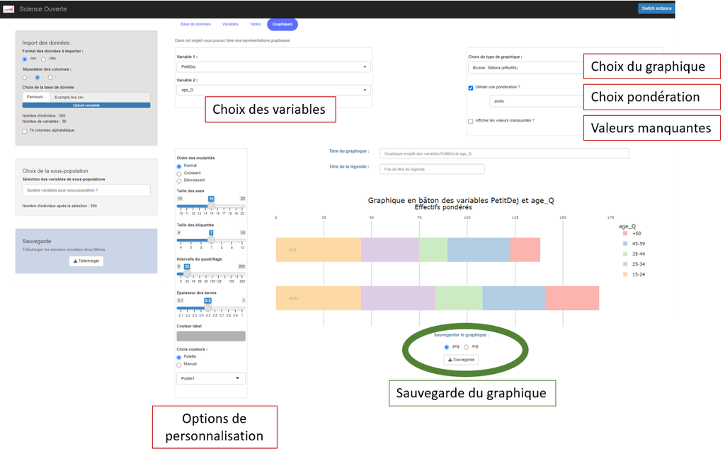

### Options de personnalisation

Différents champs permettent de modifier et embêlir le graphique, ainsi il est possible de changer :

- Le **titre de graphique**
- Le **titre de la légende**
- L’**ordre des barres**, avec un choix entre :
  - *Croissant* qui place en haut la catégorie de Variable 1 avec le moins d’effectifs
  - *Décroissant* qui place en haut la catégorie de Variable 1 avec le plus d’effectifs
  - *Normal* qui reprend l’ordre de la variable (pouvant être modifié dans l’onglet **Variables**)
- La **taille des axes**, qui change la taille de la police des axes
- La **taille des étiquettes**, qui change la taille de la police des étiquettes (nom des barres)
- L’**intervalle du quadrillage**, qui change la graduations des axes.
- L’**épaisseur des barres** (uniquement pour les graphiques en bâtons)
- La **couleur des labels** qui change la couleur des étiquettes (nom des barres)
- La **couleur catégories** de Variable 2, avec deux options :
  - *Palette* : choisir entre un ensemble de palette pré-définis.
  - *Manuel* : choix des couleurs unes à unes pour chaque catégorie.

## Sauvegarder son travail

Nous avons vu précédemment qu’il est possible de sauvegarder les résultats des tables et graphiques dans les onglets dédiés.

Cependant, il est également possible de sauvegarder la base de données utilisée pour les produire afin de garder le même sous-échantillon et les mêmes variables crées lors de la prochaine utilisation de l’application.

Pour cela, il suffit de cliquer sur le bouton *Télécharger* dans la section Sauvegarde des encadrés à gauche, pour retrouver une base modifiée (au format Excel, .xlsx) dans le dossier Téléchargement de l’ordinateur utilisé.